# FJP Dados

#### EE_ESPESC

| Ano | N | Mínimo | Média | Mediana | Máximo | D. P. | C. V. | Zero | Missing |
| --- | --- | --- | --- | --- | --- | --- | --- | --- | --- |
| 2000 | 853 | NA | NA | NA | NA | NA | NA | 0 | 853 |
| 2001 | 853 | NA | NA | NA | NA | NA | NA | 0 | 853 |
| 2002 | 853 | NA | NA | NA | NA | NA | NA | 0 | 853 |
| 2003 | 853 | NA | NA | NA | NA | NA | NA | 0 | 853 |
| 2004 | 853 | NA | NA | NA | NA | NA | NA | 0 | 853 |
| 2005 | 853 | NA | NA | NA | NA | NA | NA | 0 | 853 |
| 2006 | 853 | NA | NA | NA | NA | NA | NA | 0 | 853 |
| 2007 | 853 | NA | NA | NA | NA | NA | NA | 0 | 853 |
| 2008 | 853 | NA | NA | NA | NA | NA | NA | 0 | 853 |
| 2009 | 853 | 0 | 58,31 | 62,65 | 100 | 27,13 | 0,47 | 60 | 0 |
| 2010 | 853 | 0 | 49,48 | 51,93 | 100 | 28,72 | 0,58 | 84 | 0 |
| 2011 | 853 | 0 | 56,86 | 60,69 | 100 | 26,32 | 0,46 | 62 | 0 |
| 2012 | 853 | 0 | 60,34 | 64,46 | 100 | 25,87 | 0,43 | 52 | 0 |
| 2013 | 853 | 0 | 61,12 | 65,23 | 100 | 25,63 | 0,42 | 46 | 0 |
| 2014 | 853 | 0 | 61,91 | 66,22 | 100 | 25,13 | 0,41 | 44 | 0 |
| 2015 | 853 | 0 | 61,83 | 66,61 | 100 | 25 | 0,4 | 43 | 0 |
| 2016 | 853 | 0 | 62,57 | 67,68 | 100 | 24,77 | 0,4 | 43 | 0 |
| 2017 | 853 | 0 | 62,15 | 66,97 | 100 | 25,08 | 0,4 | 47 | 0 |
| 2018 | 853 | 0 | 62,22 | 67,35 | 100 | 24,96 | 0,4 | 43 | 0 |
| 2019 | 853 | 0 | 62,77 | 68,04 | 100 | 24,26 | 0,39 | 39 | 0 |
| 2020 | 853 | 0 | 63,72 | 69,39 | 100 | 24,05 | 0,38 | 34 | 0 |
| 2021 | 853 | 0 | 63,97 | 69,39 | 100 | 23,56 | 0,37 | 34 | 0 |
| 2022 | 853 | 0 | 63,87 | 69,3 | 100 | 23,23 | 0,36 | 33 | 0 |

#### EE_ILRHE

| Ano | N | Mínimo | Média | Mediana | Máximo | D. P. | C. V. | Zero | Missing |
| --- | --- | --- | --- | --- | --- | --- | --- | --- | --- |
| 2000 | 853 | NA | NA | NA | NA | NA | NA | 0 | 853 |
| 2001 | 853 | NA | NA | NA | NA | NA | NA | 0 | 853 |
| 2002 | 853 | NA | NA | NA | NA | NA | NA | 0 | 853 |
| 2003 | 853 | NA | NA | NA | NA | NA | NA | 0 | 853 |
| 2004 | 853 | NA | NA | NA | NA | NA | NA | 0 | 853 |
| 2005 | 853 | NA | NA | NA | NA | NA | NA | 0 | 853 |
| 2006 | 853 | NA | NA | NA | NA | NA | NA | 0 | 853 |
| 2007 | 853 | NA | NA | NA | NA | NA | NA | 0 | 853 |
| 2008 | 853 | NA | NA | NA | NA | NA | NA | 0 | 853 |
| 2009 | 853 | 0 | 0,12 | 0 | 5,24 | 0,48 | 4,12 | 759 | 0 |
| 2010 | 853 | 0 | 0,12 | 0 | 3,07 | 0,35 | 2,97 | 657 | 0 |
| 2011 | 853 | 0 | 0,12 | 0 | 2,16 | 0,31 | 2,68 | 606 | 0 |
| 2012 | 853 | 0 | 0,12 | 0 | 2,43 | 0,31 | 2,65 | 576 | 0 |
| 2013 | 853 | 0 | 0,12 | 0 | 2,2 | 0,28 | 2,38 | 484 | 0 |
| 2014 | 853 | 0 | 0,12 | 0 | 2,05 | 0,28 | 2,37 | 515 | 0 |
| 2015 | 853 | 0 | 0,12 | 0 | 2,72 | 0,33 | 2,8 | 605 | 0 |
| 2016 | 853 | 0 | 0,12 | 0 | 3,36 | 0,37 | 3,12 | 621 | 0 |
| 2017 | 853 | 0 | 0,12 | 0 | 2,17 | 0,28 | 2,42 | 504 | 0 |
| 2018 | 853 | 0 | 0,12 | 0 | 2,73 | 0,32 | 2,73 | 476 | 0 |
| 2019 | 853 | 0 | 0,12 | 0 | 3,08 | 0,31 | 2,64 | 441 | 0 |
| 2020 | 853 | 0 | 0,12 | 0 | 4,21 | 0,32 | 2,75 | 557 | 0 |
| 2021 | 853 | 0 | 0,12 | 0 | 4,18 | 0,32 | 2,75 | 556 | 0 |
| 2022 | 853 | 0 | 0,12 | 0 | 2,22 | 0,27 | 2,33 | 412 | 0 |

### Quantil

#### EE_QUANT

| Ano | 25% | 75% |
| --- | --- | --- |
| 2000 | NA | NA |
| 2001 | NA | NA |
| 2002 | NA | NA |
| 2003 | NA | NA |
| 2004 | NA | NA |
| 2005 | NA | NA |
| 2006 | NA | NA |
| 2007 | NA | NA |
| 2008 | NA | NA |
| 2009 | NA | NA |
| 2010 | NA | NA |
| 2011 | NA | NA |
| 2012 | NA | NA |
| 2013 | NA | NA |
| 2014 | NA | NA |
| 2015 | 3 | 7 |
| 2016 | 3 | 7 |
| 2017 | 3 | 7 |
| 2018 | 3 | 7 |
| 2019 | 3 | 7 |
| 2020 | 3 | 7 |
| 2021 | 4 | 11 |
| 2022 | 4 | 11 |

#### EE_PROGE

| Ano | 25% | 75% |
| --- | --- | --- |
| 2000 | NA | NA |
| 2001 | NA | NA |
| 2002 | NA | NA |
| 2003 | NA | NA |
| 2004 | NA | NA |
| 2005 | NA | NA |
| 2006 | NA | NA |
| 2007 | NA | NA |
| 2008 | NA | NA |
| 2009 | 0 | 0 |
| 2010 | 0 | 0 |
| 2011 | 0 | 2,5 |
| 2012 | 0 | 11 |
| 2013 | 0 | 29 |
| 2014 | 0 | 26 |
| 2015 | 0 | 5,5 |
| 2016 | 0 | 5 |
| 2017 | 0 | 46,5 |
| 2018 | 0 | 44 |
| 2019 | 0 | 50 |
| 2020 | 0 | 23,36 |
| 2021 | 0 | 23,38 |
| 2022 | 0 | 65 |

#### EE_ESPESC

| Ano | 25% | 75% |
| --- | --- | --- |
| 2000 | NA | NA |
| 2001 | NA | NA |
| 2002 | NA | NA |
| 2003 | NA | NA |
| 2004 | NA | NA |
| 2005 | NA | NA |
| 2006 | NA | NA |
| 2007 | NA | NA |
| 2008 | NA | NA |
| 2009 | 42,99 | 79,17 |
| 2010 | 28,89 | 72,16 |
| 2011 | 43,08 | 77,44 |
| 2012 | 47,04 | 80,59 |
| 2013 | 48,39 | 80,99 |
| 2014 | 48,55 | 81,22 |
| 2015 | 47,79 | 81,19 |
| 2016 | 49,35 | 81,52 |
| 2017 | 49,25 | 80,9 |
| 2018 | 48,66 | 81,25 |
| 2019 | 49,23 | 80,92 |
| 2020 | 50,8 | 81,62 |
| 2021 | 51,04 | 81,32 |
| 2022 | 52,01 | 80,21 |

#### EE_ILRHE

| Ano | 25% | 75% |
| --- | --- | --- |
| 2000 | NA | NA |
| 2001 | NA | NA |
| 2002 | NA | NA |
| 2003 | NA | NA |
| 2004 | NA | NA |
| 2005 | NA | NA |
| 2006 | NA | NA |
| 2007 | NA | NA |
| 2008 | NA | NA |
| 2009 | 0 | 0 |
| 2010 | 0 | 0 |
| 2011 | 0 | 0,03 |
| 2012 | 0 | 0,05 |
| 2013 | 0 | 0,09 |
| 2014 | 0 | 0,08 |
| 2015 | 0 | 0,02 |
| 2016 | 0 | 0,02 |
| 2017 | 0 | 0,09 |
| 2018 | 0 | 0,08 |
| 2019 | 0 | 0,07 |
| 2020 | 0 | 0,07 |
| 2021 | 0 | 0,07 |
| 2022 | 0 | 0,1 |

## Gráficos

Observação: os gráficos abaixo são mostrados na escala logarítmica para facilitar a visualização dos dados em certos casos. Para conferir os valores reais, consultar as tabelas descritivas.

### Gráfico de caixa (boxplot)

#### EE_QUANT

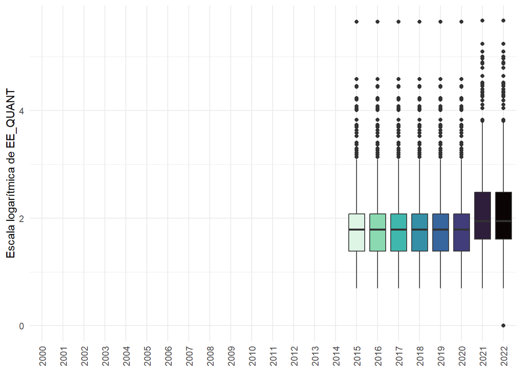

#### EE_PROGE

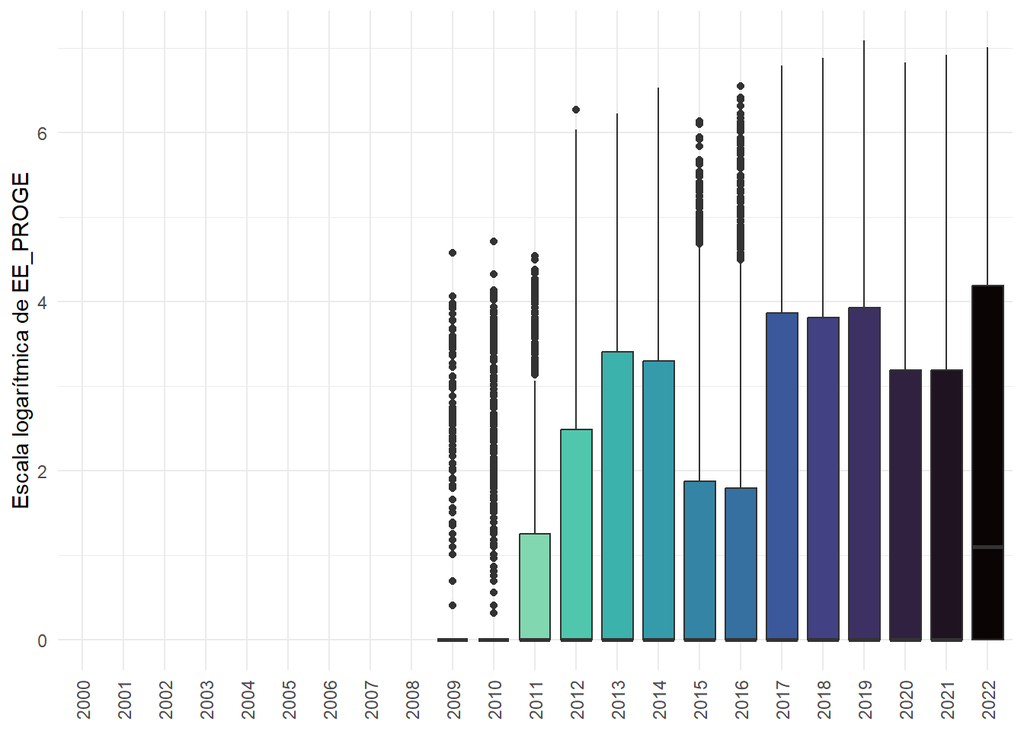

#### EE_ESPESC

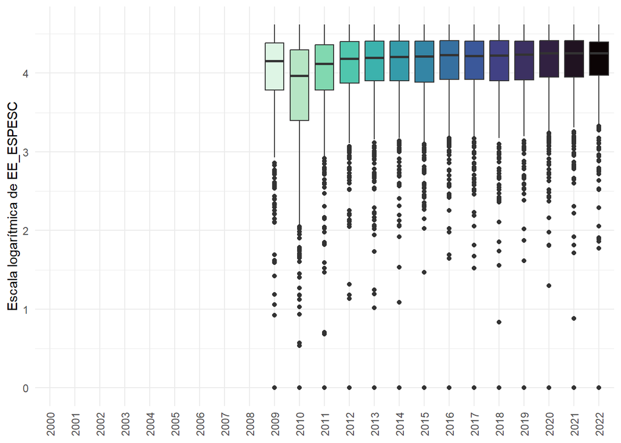

#### EE_ILRHE

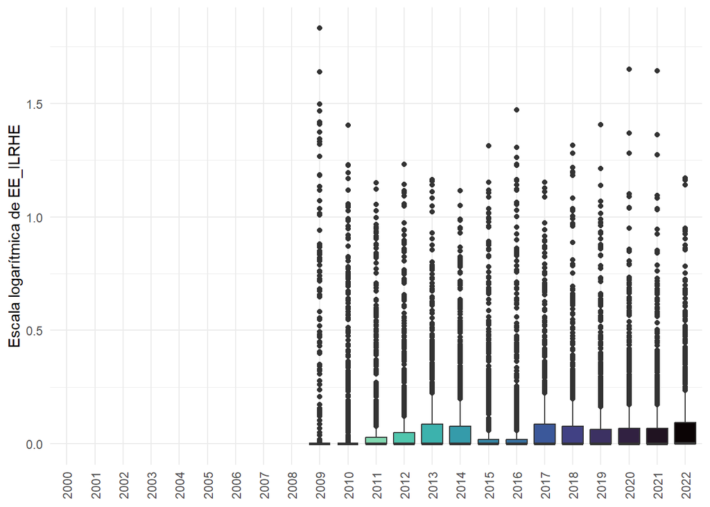

### Histograma

#### EE_QUANT

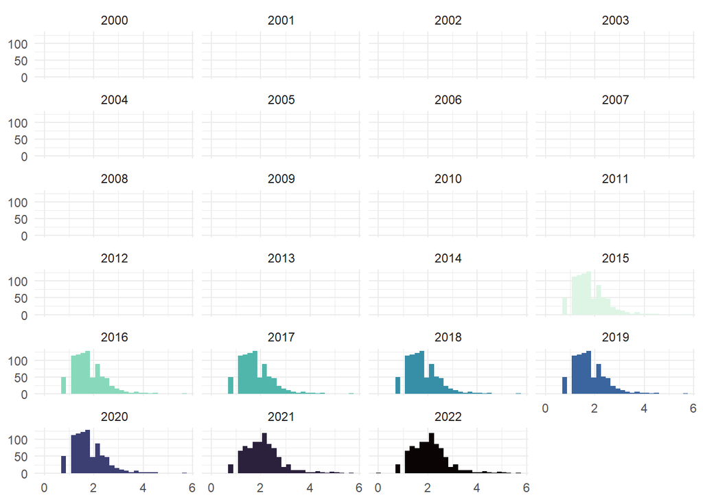

#### EE_PROGE

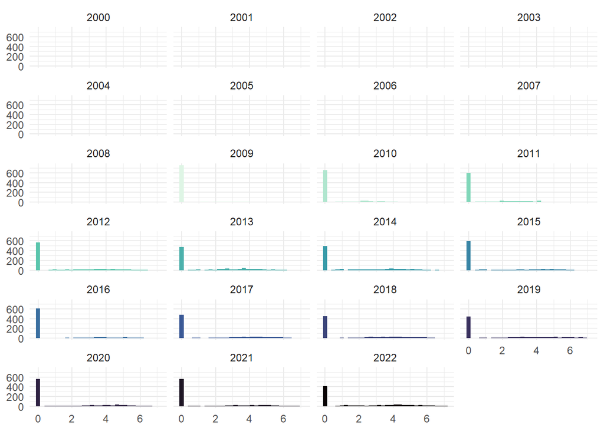

#### EE_ESPESC

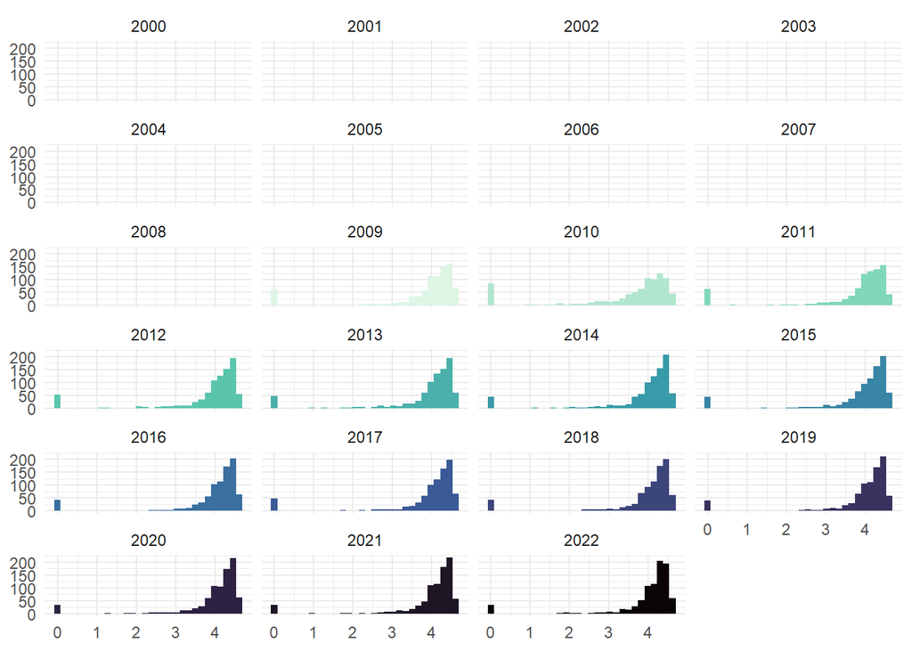

#### EE_ILRHE

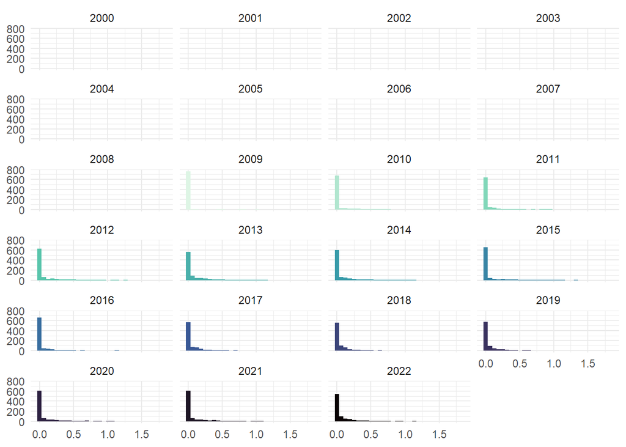